# Midterm Exam: Version 1

There are 5 questions on this exam. Each is worth 25 points. Do any four. No more than four.

Most of the questions draw on a new data set called Vote, which includes variables that are often used to explain differences in aggregate voter turnout across countries. There are 38 observations in the data set: Portugal and Taiwan appear twice (two separate elections).

In all, it has 9 variables punctuated as follows:

- Country: The name of the country.
- Year: The year of the election.
- Turnout: Aggregate voter turnout in the country.
- ElecType: The type of election (3 Categories: Parliament Election, Parliament & President, and President)
- Compulsory: Is there compulsory voting in the country, no or yes?
- GNPCap: GNP per Capita for the election year.
- Elsys: Electoral system type with 3 types, FPTP (first past the post, like Canada and the US), PR (proportional representation), and Mixed (combinations of both).
- Polarize: The level of party polarization in the country. That is the distance between the two largest parties on the left-right ideological scale.
- OldDem: New Democracy vs. Old Democracy

Download the data set with the following command:

```r
vote = read.csv("http://www.sfu.ca/~sweldon/Vote.csv", header = T)
```

## 1. Univariate Statistics

### A)

#### Using the sample of Turnout from the Vote data set, find the following for just the countries that use a PR electoral system:

mean,

```r
vote_PR <- subset(vote, Elsys == "PR")
mean(vote_PR$Turnout)
```

```
## [1] 70.92273
```

median

```r
median(vote_PR$Turnout)
```

```
## [1] 71.05
```

standard deviation,

```r
sd(vote_PR$Turnout)
```

```
## [1] 12.49468
```

and range

```r
range(vote_PR$Turnout)
```

```
## [1] 37.3 89.1
```

of the distribution (4 points each).

### B)

#### Create a histogram for the distribution of Turnout for the PR countries only (9 points).

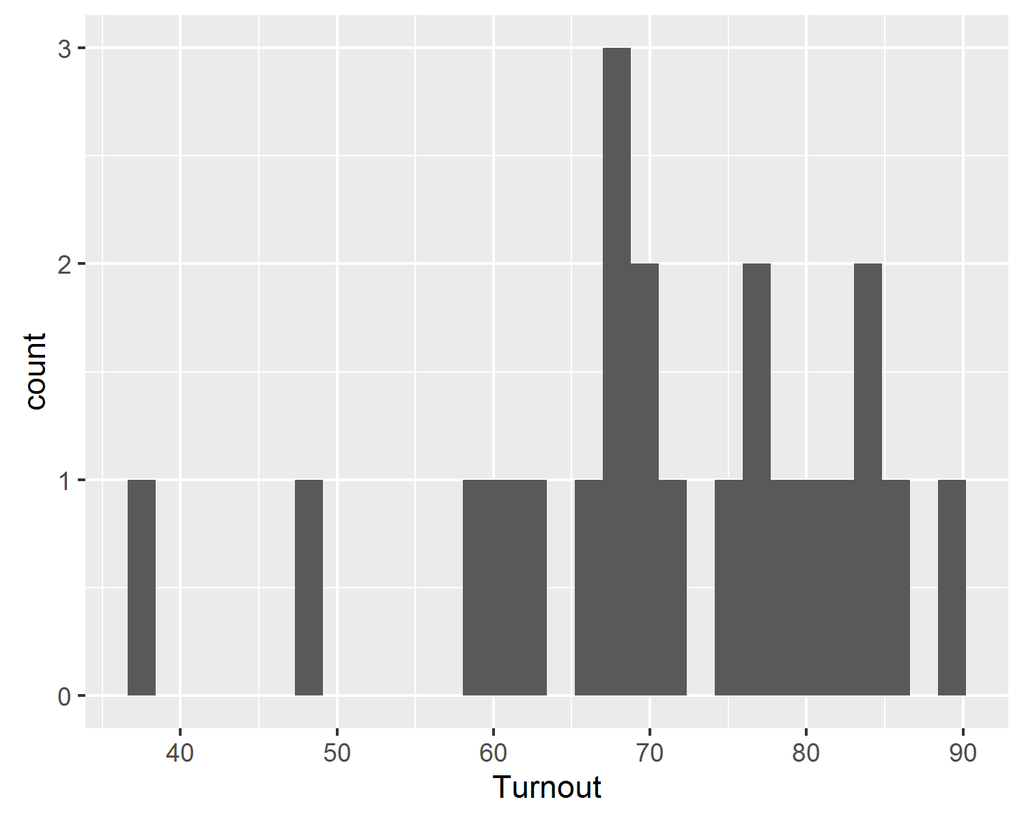

```r
library(ggplot2)
ggplot(data = vote_PR, aes(x = Turnout)) + geom_histogram()
```

## 2. Association: Regression and Correlation

### A)

#### Fit a linear model to Turnout (dependent variable) and Polarize (independent variable) (5 points),

```r
lm(formula = Turnout ~ Polarize, data = vote)
```

```
##
## Call:
## lm(formula = Turnout ~ Polarize, data = vote)
##
## Coefficients:
## (Intercept)     Polarize
##     70.2339      -0.6524
```

### B)

#### Make a scatterplot of this relationship (5 points) and add the regression line to the scatterplot (5 points),

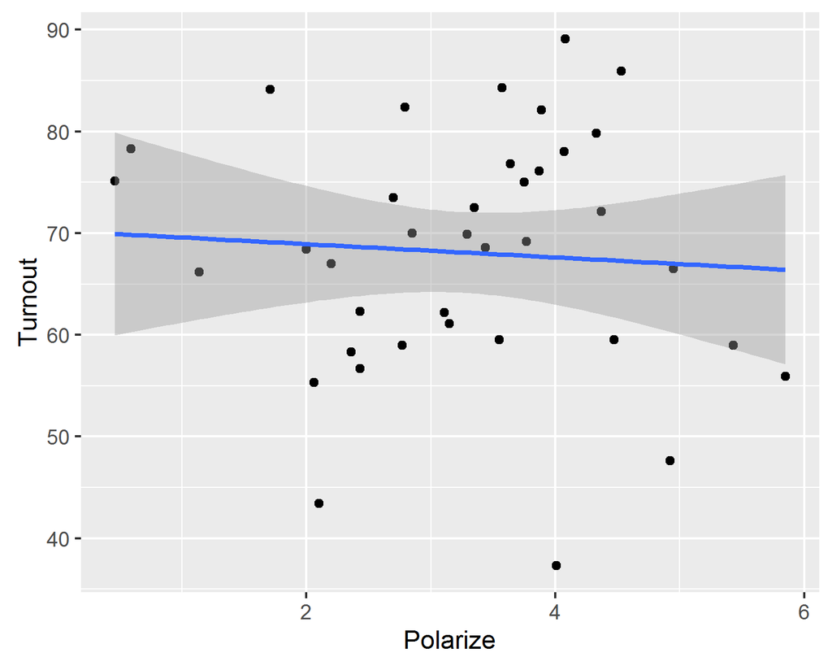

```r
ggplot(data = vote, aes(x = Polarize, y = Turnout)) +
  geom_point() +
  geom_smooth(method="lm")
```

### C)

#### What is the predicted turnout rate for a country with a polarization level of 4.25 (5 points),

```r
-0.6524*4.25+70.2339
```

```
## [1] 67.4612
```

### D)

#### Calculate the Pearson correlation coefficient (5 points).

```r
cor(x = vote$Polarize, y = vote$Turnout)
```

```
## [1] -0.06750497
```

## 3. Contingency Tables and Probability

### A)

#### Make a contingency table (with the marginals or totals) of the relationship between the election type in a country and whether it is a new or old democracy (10 Points).

```r
addmargins(table(vote$ElecType, vote$OldDem))
```

|  | New Democracy | Old Democracy | Sum |
| --- | --- | --- | --- |
| Parliament & President | 5 | 1 | 6 |
| Parliament Election | 9 | 20 | 29 |
| President Election | 2 | 1 | 3 |
| Sum | 16 | 22 | 38 |

### B)

#### Calculate the probability that a country has a Parliament only election (5 points).

```r
29/38
```

```
## [1] 0.7631579
```

### C)

#### Calculate the probability that a country has a Parliament election, given that they are a new democracy (5 Points).

Of all the 16 countries with a New Democracy… 9 countries with Parliament Election, 16 countries total. = 9/16

```r
9/16
```

```
## [1] 0.5625
```

### D)

#### Calculate the probability that a country is a new democracy, given that they have a Parliament election (5 Points).

Of the 29+6=35 countries with a Parliament Election… 5+9=14 countries that are New Democracy, 35 countries total = 14/35

```r
14/35
```

```
## [1] 0.4
```

## 4. Normal Curve, Percentile Ranks, and Z-Scores

```
Assume a population has a mean height of 1.75 meters with a standard deviation of 0.18 meters.
```

### A)

#### What is the height that most closely corresponds to a percentile rank of 70%? (6 points)

```r
qnorm(0.7, mean = 1.75, sd= 0.18)
```

```
## [1] 1.844392
```

### B)

#### What is the standard score (Z-score) that corresponds to a height of 1.58 meters? (6 points)

```r
(1.58-1.75)/0.18
```

```
## [1] -0.9444444
```

### C)

#### What is the percentile rank that most closely corresponds to a height of 1.58 meters (6 points)?

```r
pnorm(q = 1.58, mean = 1.75, sd = 0.18)*100 # times 100 to convert to percentage
```

```
## [1] 17.24713
```

### D)

##### Within what range of heights can we expect approximately 99% of the population to lie? (7 points).

```r
1.75+2.54*0.18
```

```
## [1] 2.2072
```

Of course, you need a lower limit too

```r
1.75-2.54*0.18 #note the minus
```

```
## [1] 1.2928
```

## 5. Sample Distributions

In an election between 2 candidates, let’s assume that the true distribution of preferences in the population is 52.5% for candidate A and 47.5% for candidate B.

### A)

#### Assuming a normal distribution, on average, how many sample polls out of 1000 would we expect to show candidate B to be the winner (that is, 50.01% of the vote or more), if each poll has a sample size of 750? (25 points)

**Important: the question is asking for Candiate B, who is “success” @ 0.475. If you misread the question you lose all the marks**

First, calculate the `margin of error` in the poll, using `sqrt(pq/n)`

```r
(se = sqrt(0.475*0.525/750))
```

```
## [1] 0.01823458
```

Then, calculate the probability of candidate B winning any given poll given the SE using `pnorm`. Use `lower.tail=FALSE` because we want 50.01% **or higher**

```r
p_win = pnorm(q = 0.5001, mean = 0.475, sd = se, lower.tail = FALSE)
```

Finally, multiply the probability of winning each poll by the number of polls

```r
p_win*1000
```

```
## [1] 84.33262
```

And that’s how many polls you’d expect candidate B to win